# finalArtifact

## Distribution of Yelp-associated Restaurants By Price level in Seattle

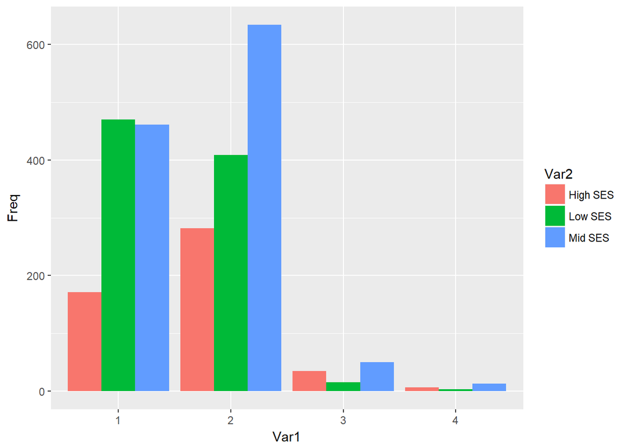

This graph is plotting the distribution of restaurants grouped by High/low/mid SES. X axis: Price level or $ sign (low= 1 sign to high= 4 signs) Y axis: the sum of restaurants in the price level

## Distribution of Yelp-associated Restaurants by Rating Seattle

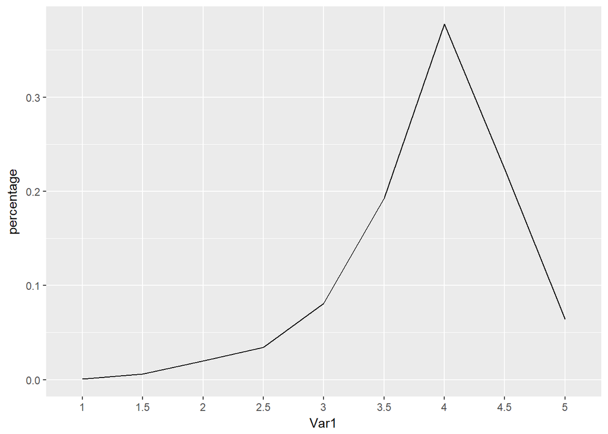

This graph is plotting the distribution of restaurants grouped by rating. X axis: rating (low to high) Y axis: percentage (frquency / sum of all restaurants) in number of restaurants for each rating

## Distribution of Yelp-associated Restaurants Rating vs Household Income Violin Plot

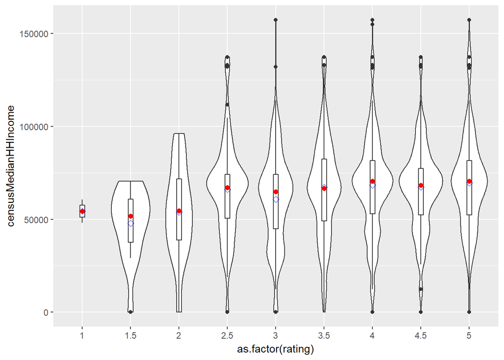

Eugenia might have a better idea for this graph.